# Week 10 R Exercise

## Load Libraries

```r
library(tidyverse)
library(janitor)
library(haven)
library(dplyr)
library(labelled)
library(ggplot2)
```

## Read Data

```r
all <- readRDS("../Data/all_data_updated.rds")
```

# Task 1: Building a Simple Logistic Regression Model

```r
# Filter out "Under 18" age group
filtered_data <- all %>% filter(age_category != "Under 18")



# Ensure age_cat is a factor without unused levels
# Convert to factor
filtered_data$age_category <- factor(filtered_data$age_category)
filtered_data$age_category <- droplevels(filtered_data$age_category)

# Create a binary variable for smoking status
filtered_data <- filtered_data %>%
  mutate(smoking01 = ifelse(smoking_status == "current", 1, 0))

# Fit the logistic regression model
model <- glm(smoking01 ~ age_category, data = filtered_data, family = "binomial")



# Print model summary
summary(model)
```

```
Call:
glm(formula = smoking01 ~ age_category, family = "binomial",
    data = filtered_data)

Coefficients:
                  Estimate Std. Error z value Pr(>|z|)
(Intercept)       -1.58605    0.07781 -20.384  < 2e-16 ***
age_category30-44  0.31093    0.10179   3.055 0.002254 **
age_category45-59  0.34207    0.10216   3.349 0.000812 ***
age_category60+   -0.21783    0.10387  -2.097 0.035976 *
---
Signif. codes:  0 ‘***’ 0.001 ‘**’ 0.01 ‘*’ 0.05 ‘.’ 0.1 ‘ ’ 1

(Dispersion parameter for binomial family taken to be 1)

    Null deviance: 5357.4  on 5584  degrees of freedom
Residual deviance: 5310.1  on 5581  degrees of freedom
  (10 observations deleted due to missingness)
AIC: 5318.1

Number of Fisher Scoring iterations: 4
```

### Intercept (-1.58605):

The intercept represents the log-odds of being a current smoker for the reference age group (18-29 years).

Odds of smoking for 18-29 group=exp(−1.58605)≈0.204 This means that the odds of being a current smoker in the 18-29 age group are approximately 0.2 to 1 (i.e., about 20%)

### Age Category Effects:

The coefficients for the age_category variable represent the difference in log-odds of being a current smoker compared to the reference group (18-29).

#### Age Group 30-44 (0.31093):

The log-odds of being a current smoker are higher by 0.31 compared to the 18-29 group. Converting to odds ratio: exp(0.31093)≈1.364 This means the odds of being a current smoker are about 36% higher in the 30-44 age group compared to the 18-29 group. p=0.002: Statistically significant increase in odds of smoking compared to the 18-29 group.

#### Age Group 45-59 (0.34207):

The log-odds of being a current smoker are higher by 0.34 compared to the 18-29 group. Odds ratio:exp(0.34207)≈1.408 The odds of being a current smoker are about 41% higher in the 45-59 group compared to the 18-29 group. p=0.0008: Statistically significant increase in odds of smoking compared to the 18-29 group.

#### Age Group 60+ (-0.21783):

The log-odds of being a current smoker are lower by 0.22 compared to the 18-29 group. Odds ratio:exp(−0.21783)≈0.804 This means the odds of being a current smoker are about 20% lower in the 60+ group compared to the 18-29 group. p=0.036: Statistically significant decrease in odds of smoking compared to the 18-29 group.

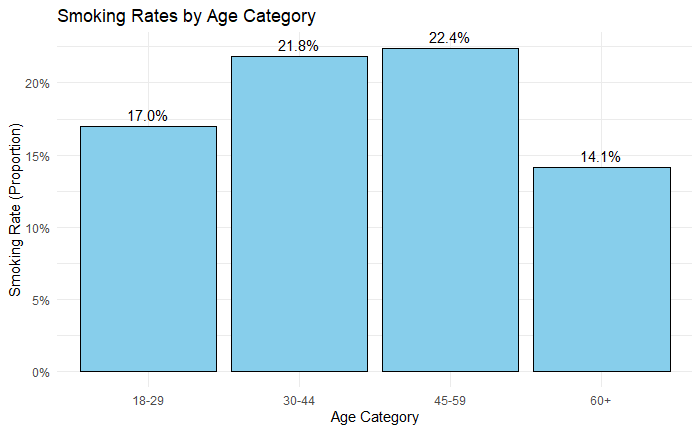

```r
# Predict probabilities for each age category
predicted_probs <- filtered_data %>%
  group_by(age_category) %>%
  summarize(
    smoking_rate = mean(smoking01, na.rm = TRUE)
  )

# Plot the smoking rates by age category
ggplot(predicted_probs, aes(x = age_category, y = smoking_rate)) +
  geom_bar(stat = "identity", fill = "skyblue", color = "black") +
  geom_text(aes(label = scales::percent(smoking_rate, accuracy = 0.1)),
            vjust = -0.5, size = 4) +
  labs(
    title = "Smoking Rates by Age Category",
    x = "Age Category",
    y = "Smoking Rate (Proportion)"
  ) +
  scale_y_continuous(labels = scales::percent_format()) +
  theme_minimal()
```

# Task 2: Calculating and Interpreting Odds Ratios with Confidence Intervals

```r
# Calculate odds ratios and 95% confidence intervals
odds_ratios <- exp(coef(model))

conf_int <- exp(confint(model))
# Create a table for reporting
results <- data.frame(
  Odds_Ratio = odds_ratios,
  CI_Lower = conf_int[, 1],
  CI_Upper = conf_int[, 2]
)


print(results)
```

|  | Odds_Ratio | CI_Lower | CI_Upper |
| --- | --- | --- | --- |
| (Intercept) | 0.2047325 | 0.1753101 | 0.2378700 |
| age_category30-44 | 1.3646974 | 1.1187170 | 1.6676010 |
| age_category45-59 | 1.4078628 | 1.1532634 | 1.7215444 |
| age_category60+ | 0.8042623 | 0.6563707 | 0.9864293 |

Intercept: The confidence interval does not include 1, indicating statistical significance.

Age Group 30-44: The confidence interval does not include 1, so the result is statistically significant.

Age Group 45-59: The confidence interval does not include 1, so this result is statistically significant.

Age Group 60+: The confidence interval does not include 1, so this result is statistically significant.

# Task 3: Creating a Table of Log-Odds, Odds, and Probabilities

```r
# Extract model coefficients
intercept <- coef(model)[1]  # Intercept term
coefficients <- coef(model)[-1]  # Coefficients for age categories



# Calculate log-odds, odds, and probabilities for each age category
log_odds <- c(intercept, intercept + coefficients)  # Log-odds for each age category

odds <- exp(log_odds)  # Convert log-odds to odds

probabilities <- odds / (1 + odds)  # Convert odds to probabilities



# Create a data frame with age category names and calculated values

results <- data.frame(
  Log_Odds = log_odds,
  Odds = odds,
  Probability = probabilities
)


print(results)
```

|  | Log_Odds | Odds | Probability |
| --- | --- | --- | --- |
| (Intercept) | -1.586051 | 0.2047325 | 0.1699402 |
| age_category30-44 | -1.275118 | 0.2793979 | 0.2183824 |
| age_category45-59 | -1.243978 | 0.2882353 | 0.2237443 |
| age_category60+ | -1.803881 | 0.1646586 | 0.1413793 |

# Task 4: Adding a Categorical Predictor

```r
# Fit a logistic regression model with a categorical predictor
model_gender <- glm(smoking01 ~ age_category + gender, data = filtered_data, family = "binomial")



# Print model summary
summary(model_gender)
```

```
Call:
glm(formula = smoking01 ~ age_category + gender, family = "binomial",
    data = filtered_data)

Coefficients:
                  Estimate Std. Error z value Pr(>|z|)
(Intercept)       -1.31222    0.08381 -15.657  < 2e-16 ***
age_category30-44  0.32241    0.10246   3.147 0.001651 **
age_category45-59  0.34583    0.10281   3.364 0.000769 ***
age_category60+   -0.22811    0.10444  -2.184 0.028958 *
genderfemale      -0.57743    0.07027  -8.218  < 2e-16 ***
---
Signif. codes:  0 ‘***’ 0.001 ‘**’ 0.01 ‘*’ 0.05 ‘.’ 0.1 ‘ ’ 1

(Dispersion parameter for binomial family taken to be 1)

    Null deviance: 5357.4  on 5584  degrees of freedom
Residual deviance: 5241.4  on 5580  degrees of freedom
  (10 observations deleted due to missingness)
AIC: 5251.4

Number of Fisher Scoring iterations: 4
```

```r
# Calculate odds ratios and 95% confidence intervals
odds_ratios_gender <- exp(coef(model_gender))
conf_int_gender <- exp(confint(model_gender))
# Create a table for reporting
results_gender <- data.frame(
  Odds_Ratio = odds_ratios_gender,
  CI_Lower = conf_int_gender[, 1],
  CI_Upper = conf_int_gender[, 2]
)


print(results_gender)
```

|  | Odds_Ratio | CI_Lower | CI_Upper |
| --- | --- | --- | --- |
| (Intercept) | 0.2692230 | 0.2279091 | 0.3166008 |
| age_category30-44 | 1.3804542 | 1.1301593 | 1.6890551 |
| age_category45-59 | 1.4131633 | 1.1561053 | 1.7302505 |
| age_category60+ | 0.7960366 | 0.6489160 | 0.9774308 |
| genderfemale | 0.5613370 | 0.4888997 | 0.6439774 |

Compared to the reference category (males aged 18-29): Males aged 30-44 and 45-59 are 38% and 41.3% more likely to smoke, respectively. Males aged 60+ are 20.4% less likely to smoke compared to the reference group. Females are 44% less likely to smoke compared to males in the same age category.